# MiSiPi.RNA Documentation

[figure not shown]

## Installation:

Install Devtools, MiSiPi.RNA packages and load library

```r
install.packages("devtools")

devtools::install_github("stupornova33/MiSiPi.RNA")

library(MiSiPi.RNA)
```

MiSiPi.RNA is designed to run efficiently on personal laptops or high performance compute clusters. The current version supports Windows, Linux, and Mac operating systems.

## Data preparation and basic usage

1. Align adapter- trimmed and quality- filtered small RNA reads to reference genome, convert to BAM format, and index.
2. If you are interested in characterizing novel or un-annotated species, you should create a BED file of regions of interest using a pipeline similar to the method shown in the Cluster Calling section of this document. Otherwise, reference annotations can be used.
3. The regions of interest should be formatted as a 3-column BED file (but if there are more columns, they will be ignored) and all lines must contain the same number of fields. Chromosome names in the BED file must match the chromosome names in the reference genome.
4. Install the [ViennaRNA](https://www.tbi.univie.ac.at/RNA/) package on your system.

(Optional) The miRNA module outputs structure plots from RNAfold as .eps files. There is currently no built-in R way to convert these files to png or pdf. If you want to be able to convert them using MiSiPi.RNA, you can install the freely available packages [Ghostscript](https://www.ghostscript.com/) and [ImageMagick](https://imagemagick.org/index.php) and use our included function ps2png.

5. (Optional) Prepare reference annotation BED file (useful for the hairpin RNA and/or cisNAT siRNA plots). The annotation plot is at a rough-draft stage, so we recommending extracting features (e.g. transcripts) which are most relevant to your interest and removing redundant features for clarity.

To see an example of how this file should be formatted, run:

```r
annot = system.file("extdata", "processed_dmel.txt", package = "MiSiPi.RNA")
```

Once you have gathered all of these materials, you are ready to run your small RNA module/s of choice. As an example, if you are interested in miRNAs, you would run:

```r
## Choose your Pokemon
## setvars just helps format and check the parameters you provide
## Descriptions of the different parameters are provided on the main Github page.

vars <- set_vars(
    roi = "path/to/bed",
    bam_file = "path/to/bam",
    genome = "path/to/genome",
    plot_output = TRUE,
    path_to_RNAfold = "path/to/ViennaRNA/RNAfold.exe",
    path_to_RNAplot = "path/to/ViennaRNA/RNAplot.exe",
    pi_pal = "BlYel",
    si_pal = "RdYlBl",
    annotate_region = TRUE,
    weight_reads = "none",
    gtf_file = "path/to/gtf",
    write_fastas = FALSE,
    out_type = "pdf"
)

misipi_rna(vars) - Default method is "all"

misipi_rna(vars, method = "siRNA")
```

Output will be stored in a directory called “miRNA_outputs” (or “siRNA_outputs” or “piRNA_outputs”).

This module will produce an output directory called “run_all” in your working directory with subfolders for each type of small RNA.

## Output files from each module

By default, a logfile is made for each module (e.g. “miRNA_logfile.txt”). This is primarily for troubleshooting issues. The program writes important messages into this file.

### miRNA module

If plot_output is set to true, there will be a png or pdf file for each locus in the BED file you provided in the arguments, however it is important to note that if there are too few reads mapped for the program to progress in calculations and plotting, no plot will be made. Since this program is designed to be able to run without strand information, there will be a file ending with “+_combined” or “-_combined” for each locus (assuming adequate read coverage). This behavior may be changed in the future.

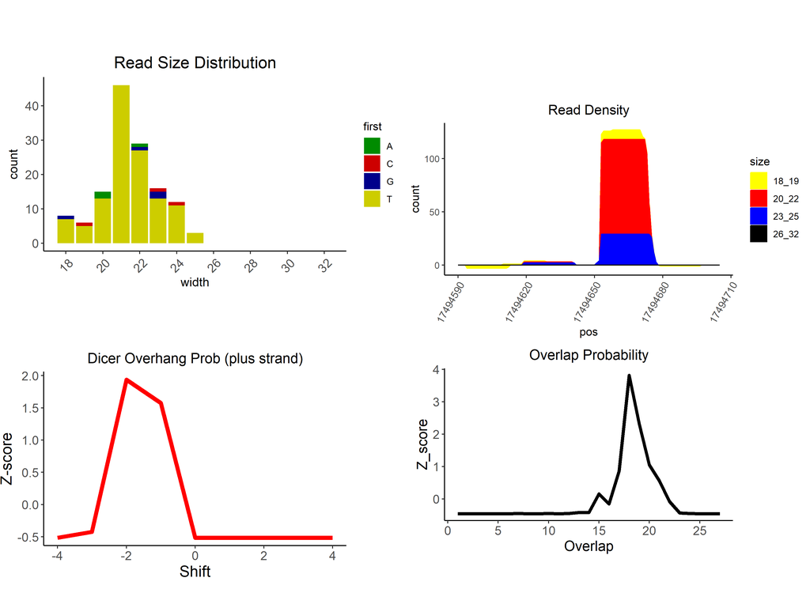

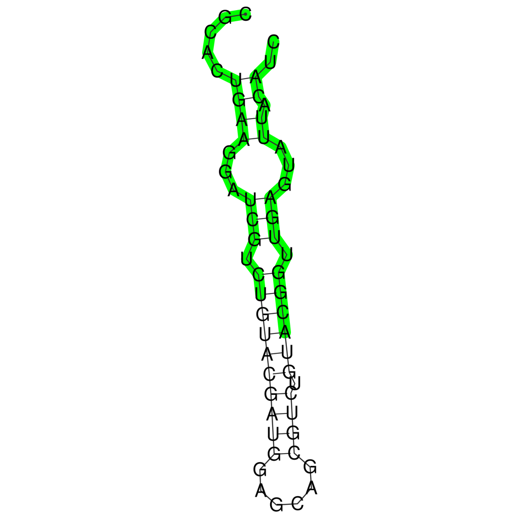

Other outputs of the miRNA module are “alt_miRNAs_coord.bed” and “miRNA_dicerz.txt”. When the program encounters “isomirs” (slightly different variations in the miRNA), it chooses the most abundant variant for plotting and statistics and outputs the isomir coordinates as a BED file. If interested, you could use this file for further characterization by MiSiPi.RNA or other programs of your choosing. “miRNA_dicerz.txt” is a table containing the numbers used to generate the Dicer Probability plot above.

### siRNA module

The two known primary types of endogenous siRNAs are the bidirectionally transcribed cis-natural antisense transcripts (cisNATs) and long hairpin RNAs formed from complementary inverted repeats. Both are processed from their double-stranded precursors into 21nt length small RNAs by an RNAse enzyme (in fruitflies, Dcr-2). The siRNA program first processes reads from both strands and performs various calculations, followed by hairpin-RNA specific processing (e.g. single-strand processing).

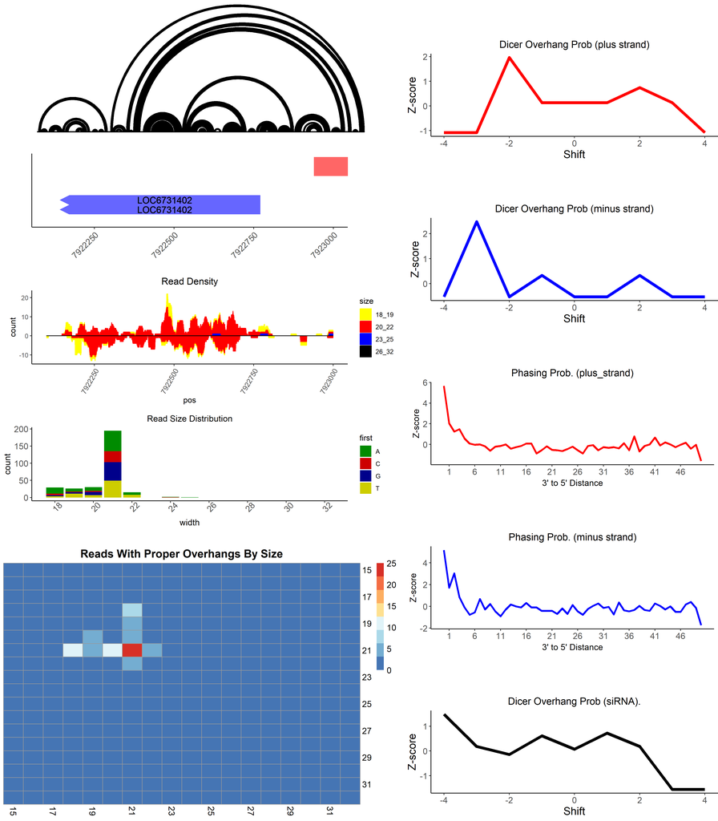

For cisNAT siRNAs, a heatmap is made. For this plot, the program identifies overlapping read pairs which have a characteristic “Dicer signature” (see bioRxiv article) from opposite strands and tabulates their sizes. This plot is useful for counting the number of cisNAT siRNA pairs at a locus. It is important to note that if the plot for a locus of interest does not have a heatmap, it is due to lack of reads on one strand.

The other plots depicted are Z-scores for Dicer processing by sense (top right), antisense (middle top right) strands, phased processing by strand, and Dicer signature of sense/antisense overlapping reads (bottom right).

Other output files from the siRNA module are the values by locus of the Dicer and phasing probability plots for hairpin RNAs (“minus_hp_phasedz.txt”, “plus_hp_phasedz.txt”, “minus_hp_dicerz.txt”, “plus_hp_dicerz.txt”) and cisNAT siRNAs (“siRNA_dicerz.txt”) as well as the raw count matrix for the siRNA heatmap, one line per locus (“siRNA_heatmap.txt”). Finally, “siRNA_read_size_distributions.txt” contains the read size distribution of each locus from 16nt-32nt.